# Module 1 - Introduction to Statistics

So let’s do an internet course; Academic Lesson’s “Biostatistics Tutorial Full course for Beginners to Experts”. But we’ll use the data I’ve collected so far and if I need any more I’ll download any missing dataset types described.

The first module is the introduction and only really gives definitions:

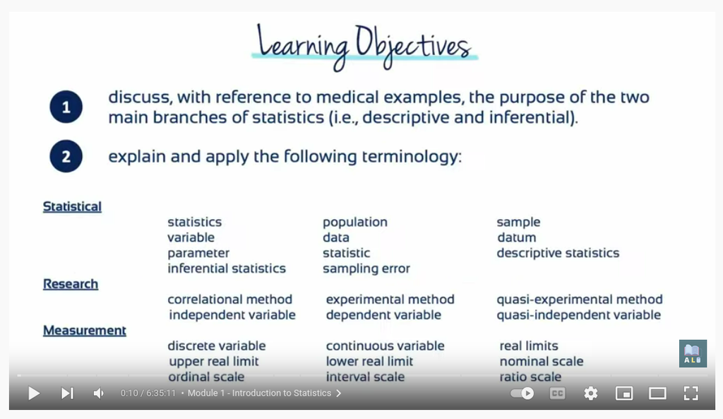

Module 1 Learning Objectives

All of Which is all quite nice and defined as:

**Statistical**

- Statistic: A characteristic that describes a sample
- Parameter: A characteristic that describes a population
- Descriptive Statistics, describing and communicating information simply
- Inferential Statistics, drawing conclusions from data and inferring
- Population: A set of all individuals of interest
- Sample: A selection of individuals from a population
- Variable: Characteristics that change across conditions
- Data: A collection of observations
- Datum: One observation of information
- Sampling Error: The discrepancy between the true population parameter and the sample statistic

**Research**

- Correlation Method, examines two variables as they exist naturally are observed to determine if relationships exist between them.
- Experimental Method, demonstrates a cause and effect relationship between two variables
- Quasi-Experimental Method: Non experimental study that examines pre-existing groups
- Independent Variable: What is manipulated
- Dependent Variable: What is measured
- Quasi-Independent Variable: Observations that are inseparable from an individual and cannot reasonably be manipulated

**Measurement**

- Discrete Variable: Can only take on whole numbers, no fractions of decimals
- Continuous Variable: Has an infinite number of values between two values
- Real Limits: Borders set on continuous variables
- Upper Real Limit: the Real limit with the higher value
- Ordinal Scale: Values are ordered by some measurement of magnitude
- Lower Real Limit: the Real limit with the lower value
- Interval Scale: Constitutes of ordered categories that are intervals of the same size
- Nominal Scale: Values are categorized only by their names
- Ration Scale: an interval scale with an absolute zero point that is meaningful

All that said, all of this was r-notebooks’ HTML. It’s pretty easy enough to simply the copy and paste into the ‘HTML’ section on the WYSIWYG editor.